# Working report

### Q7. What types of public transportation do you regularly use?

```
##                Q7_r
## Q7_q             No Yes
##   Q7_1_Bus       57 137
##   Q7_2_Carpool  184  10
##   Q7_3_Subway   131  63
##   Q7_4_Train    139  55
##   Q7_5_Taxi     169  25
##   Q7_6_Airplane 175  19
##   Q7_7_Other    179  15
```

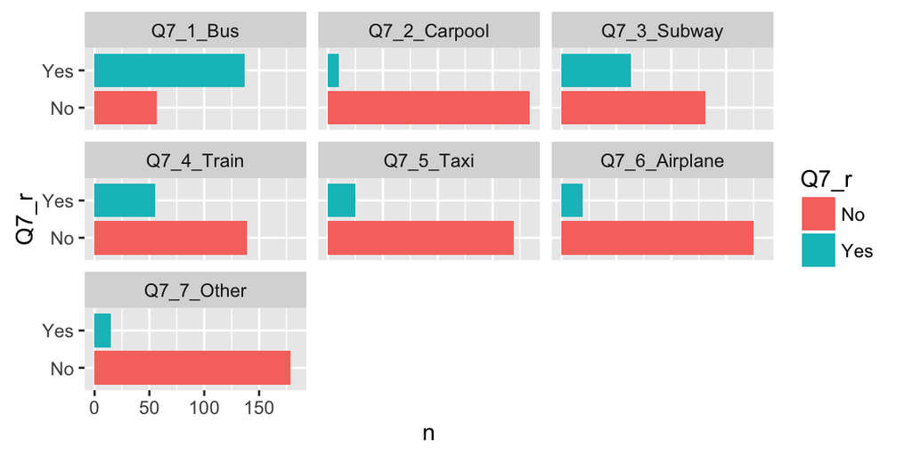

```
## , , Q7_r = No
##
##         Q7_q
## PPGENDER Q7_1_Bus Q7_2_Carpool Q7_3_Subway Q7_4_Train Q7_5_Taxi
##   Female       27           91          68         75        81
##   Male         30           93          63         64        88
##         Q7_q
## PPGENDER Q7_6_Airplane Q7_7_Other
##   Female            89         87
##   Male              86         92
##
## , , Q7_r = Yes
##
##         Q7_q
## PPGENDER Q7_1_Bus Q7_2_Carpool Q7_3_Subway Q7_4_Train Q7_5_Taxi
##   Female       69            5          28         21        15
##   Male         68            5          35         34        10
##         Q7_q
## PPGENDER Q7_6_Airplane Q7_7_Other
##   Female             7          9
##   Male              12          6
```

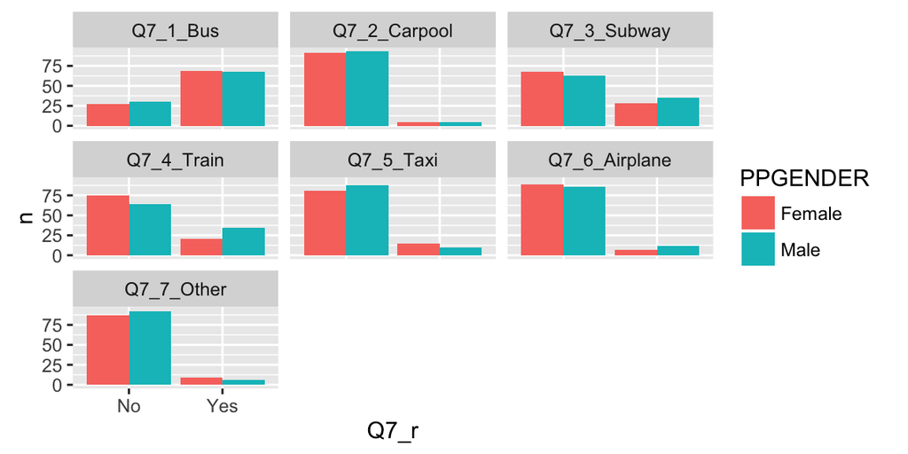

```
## , , Q7_r = No
##
##                         Q7_q
## PPETHM                   Q7_1_Bus Q7_2_Carpool Q7_3_Subway Q7_4_Train
##   White, Non-Hispanic          33           91          65         67
##   Black, Non-Hispanic           5           35          26         27
##   Hispanic                      9           27          21         23
##   Other, Non-Hispanic           6           13           7          7
##   2+ Races, Non-Hispanic        4           18          12         15
##                         Q7_q
## PPETHM                   Q7_5_Taxi Q7_6_Airplane Q7_7_Other
##   White, Non-Hispanic           84            81         85
##   Black, Non-Hispanic           32            36         33
##   Hispanic                      27            31         32
##   Other, Non-Hispanic           12            12         13
##   2+ Races, Non-Hispanic        14            15         16
##
## , , Q7_r = Yes
##
##                         Q7_q
## PPETHM                   Q7_1_Bus Q7_2_Carpool Q7_3_Subway Q7_4_Train
##   White, Non-Hispanic          62            4          30         28
##   Black, Non-Hispanic          31            1          10          9
##   Hispanic                     23            5          11          9
##   Other, Non-Hispanic           7            0           6          6
##   2+ Races, Non-Hispanic       14            0           6          3
##                         Q7_q
## PPETHM                   Q7_5_Taxi Q7_6_Airplane Q7_7_Other
##   White, Non-Hispanic           11            14         10
##   Black, Non-Hispanic            4             0          3
##   Hispanic                       5             1          0
##   Other, Non-Hispanic            1             1          0
##   2+ Races, Non-Hispanic         4             3          2
```

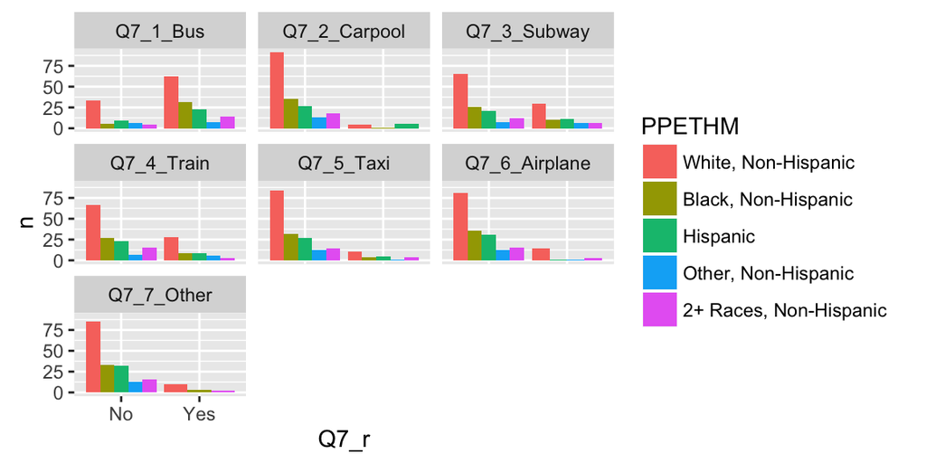

```
## , , Q7_r = No
##
##                       Q7_q
## PPINCIMP               Q7_1_Bus Q7_2_Carpool Q7_3_Subway Q7_4_Train
##   Less than $5,000            0           10           9          8
##   $5,000 to $7,499            3            2           3          2
##   $7,500 to $9,999            2            4           3          2
##   $10,000 to $12,499          3            9           9          8
##   $12,500 to $14,999          0            5           5          4
##   $15,000 to $19,999          1            4           4          4
##   $20,000 to $24,999          2            7           7          6
##   $25,000 to $29,999          0            7           7          7
##   $30,000 to $34,999          1            6           6          6
##   $35,000 to $39,999          2           12           7          9
##   $40,000 to $49,999          4            6           5          5
##   $50,000 to $59,999          6           17          12         12
##   $60,000 to $74,999          2           19          15         17
##   $75,000 to $84,999          4           11           5          8
##   $85,000 to $99,999          3            9           6          7
##   $100,000 to $124,999        8           21          11         11
##   $125,000 to $149,999        3            9           6          6
##   $150,000 to $174,999        4            9           4          7
##   $175,000 or more            9           17           7         10
##                       Q7_q
## PPINCIMP               Q7_5_Taxi Q7_6_Airplane Q7_7_Other
##   Less than $5,000             9             9          9
##   $5,000 to $7,499             3             3          2
##   $7,500 to $9,999             3             4          3
##   $10,000 to $12,499           7             9          7
##   $12,500 to $14,999           5             5          5
##   $15,000 to $19,999           3             4          4
##   $20,000 to $24,999           8             8          7
##   $25,000 to $29,999           6             8          8
##   $30,000 to $34,999           4             6          7
##   $35,000 to $39,999          11            10         11
##   $40,000 to $49,999           7             7          7
##   $50,000 to $59,999          13            15         16
##   $60,000 to $74,999          19            20         16
##   $75,000 to $84,999           9            10         12
##   $85,000 to $99,999          10             8         10
```

[output cut: 34 more lines]

```
##   $12,500 to $14,999           0             0          0
##   $15,000 to $19,999           1             0          0
##   $20,000 to $24,999           0             0          1
##   $25,000 to $29,999           2             0          0
##   $30,000 to $34,999           3             1          0
##   $35,000 to $39,999           1             2          1
##   $40,000 to $49,999           0             0          0
##   $50,000 to $59,999           4             2          1
##   $60,000 to $74,999           1             0          4
##   $75,000 to $84,999           3             2          0
##   $85,000 to $99,999           1             3          1
##   $100,000 to $124,999         1             2          1
##   $125,000 to $149,999         0             0          0
##   $150,000 to $174,999         1             3          1
##   $175,000 or more             3             3          0
```

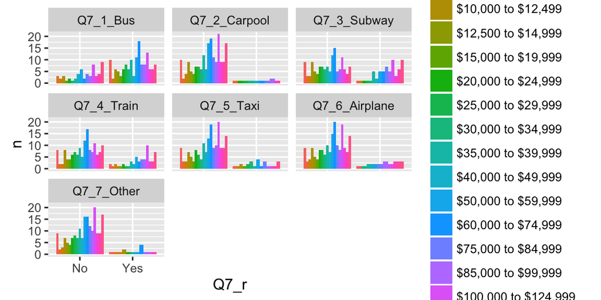

### Q8. For what types of activities do you regularly use public transportation?

```
##                       Q8_r
## Q8_q                    No Yes
##   Q8_1_Work             89 105
##   Q8_2_School          158  36
##   Q8_3_Shopping        107  87
##   Q8_4_Visiting.people 125  69
##   Q8_5_Recreation      127  67
##   Q8_6_Other           175  19
```

```
## , , Q8_r = No
##
##         Q8_q
## PPGENDER Q8_1_Work Q8_2_School Q8_3_Shopping Q8_4_Visiting.people
##   Female        53          78            43                   60
##   Male          36          80            64                   65
##         Q8_q
## PPGENDER Q8_5_Recreation Q8_6_Other
##   Female              64         84
##   Male                63         91
##
## , , Q8_r = Yes
##
##         Q8_q
## PPGENDER Q8_1_Work Q8_2_School Q8_3_Shopping Q8_4_Visiting.people
##   Female        43          18            53                   36
##   Male          62          18            34                   33
##         Q8_q
## PPGENDER Q8_5_Recreation Q8_6_Other
##   Female              32         12
##   Male                35          7
```

```
## , , Q8_r = No
##
##                         Q8_q
## PPETHM                   Q8_1_Work Q8_2_School Q8_3_Shopping
##   White, Non-Hispanic           47          81            55
##   Black, Non-Hispanic           17          29            21
##   Hispanic                      14          25            15
##   Other, Non-Hispanic            4           7             9
##   2+ Races, Non-Hispanic         7          16             7
##                         Q8_q
## PPETHM                   Q8_4_Visiting.people Q8_5_Recreation Q8_6_Other
##   White, Non-Hispanic                      64              58         84
##   Black, Non-Hispanic                      21              26         33
##   Hispanic                                 20              24         30
##   Other, Non-Hispanic                      11              11         13
##   2+ Races, Non-Hispanic                    9               8         15
##
## , , Q8_r = Yes
##
##                         Q8_q
## PPETHM                   Q8_1_Work Q8_2_School Q8_3_Shopping
##   White, Non-Hispanic           48          14            40
##   Black, Non-Hispanic           19           7            15
##   Hispanic                      18           7            17
##   Other, Non-Hispanic            9           6             4
##   2+ Races, Non-Hispanic        11           2            11
##                         Q8_q
## PPETHM                   Q8_4_Visiting.people Q8_5_Recreation Q8_6_Other
##   White, Non-Hispanic                      31              37         11
##   Black, Non-Hispanic                      15              10          3
##   Hispanic                                 12               8          2
##   Other, Non-Hispanic                       2               2          0
##   2+ Races, Non-Hispanic                    9              10          3
```

```
## , , Q8_r = No
##
##                       Q8_q
## PPINCIMP               Q8_1_Work Q8_2_School Q8_3_Shopping
##   Less than $5,000             8           8             3
##   $5,000 to $7,499             1           2             2
##   $7,500 to $9,999             2           4             1
##   $10,000 to $12,499           7           8             7
##   $12,500 to $14,999           3           4             2
##   $15,000 to $19,999           3           2             0
##   $20,000 to $24,999           4           7             5
##   $25,000 to $29,999           5           8             0
##   $30,000 to $34,999           3           7             4
##   $35,000 to $39,999           2          10             6
##   $40,000 to $49,999           4           4             3
##   $50,000 to $59,999           9          12             9
##   $60,000 to $74,999          10          15             9
##   $75,000 to $84,999           3           9             5
##   $85,000 to $99,999           3           8             9
##   $100,000 to $124,999         9          17            16
##   $125,000 to $149,999         4           8             5
##   $150,000 to $174,999         3           9             8
##   $175,000 or more             6          16            13
##                       Q8_q
## PPINCIMP               Q8_4_Visiting.people Q8_5_Recreation Q8_6_Other
##   Less than $5,000                        5               8          9
##   $5,000 to $7,499                        2               3          2
##   $7,500 to $9,999                        2               3          4
##   $10,000 to $12,499                      6               7          3
##   $12,500 to $14,999                      3               4          4
##   $15,000 to $19,999                      3               2          3
##   $20,000 to $24,999                      6               6          6
##   $25,000 to $29,999                      6               4          8
##   $30,000 to $34,999                      3               4          7
##   $35,000 to $39,999                      7               7         12
##   $40,000 to $49,999                      6               5          7
##   $50,000 to $59,999                     12              13         16
##   $60,000 to $74,999                      9              14         20
##   $75,000 to $84,999                      4               3         12
##   $85,000 to $99,999                      9              10         10
```

[output cut: 34 more lines]

```
##   $12,500 to $14,999                      2               1          1
##   $15,000 to $19,999                      1               2          1
##   $20,000 to $24,999                      2               2          2
##   $25,000 to $29,999                      2               4          0
##   $30,000 to $34,999                      4               3          0
##   $35,000 to $39,999                      5               5          0
##   $40,000 to $49,999                      1               2          0
##   $50,000 to $59,999                      5               4          1
##   $60,000 to $74,999                     11               6          0
##   $75,000 to $84,999                      8               9          0
##   $85,000 to $99,999                      2               1          1
##   $100,000 to $124,999                    2               4          2
##   $125,000 to $149,999                    4               5          2
##   $150,000 to $174,999                    3               6          0
##   $175,000 or more                        6               8          1
```

### Q9. Do other members of your household regularly use public transportation?

```
## Q9
## Don_t know         No        Yes
##         32       1935        183
```

### Q10. What types of public transportation do other members of your household regularly use?

```
##                   Q10_r
## Q10_q               No Yes
##   Q10_1_Bus         48 135
##   Q10_2_Carpool    166  17
##   Q10_3_Subway     130  53
##   Q10_4_Train      137  46
##   Q10_5_Taxi       157  26
##   Q10_6_Airplane   164  19
##   Q10_7_Don_t.know 182   1
##   Q10_8_Other      172  11
```

```
## , , Q10_r = No
##
##         Q10_q
## PPGENDER Q10_1_Bus Q10_2_Carpool Q10_3_Subway Q10_4_Train Q10_5_Taxi
##   Female        26            91           70          74         83
##   Male          22            75           60          63         74
##         Q10_q
## PPGENDER Q10_6_Airplane Q10_7_Don_t.know Q10_8_Other
##   Female             91               99          92
##   Male               73               83          80
##
## , , Q10_r = Yes
##
##         Q10_q
## PPGENDER Q10_1_Bus Q10_2_Carpool Q10_3_Subway Q10_4_Train Q10_5_Taxi
##   Female        73             8           29          25         16
##   Male          62             9           24          21         10
##         Q10_q
## PPGENDER Q10_6_Airplane Q10_7_Don_t.know Q10_8_Other
##   Female              8                0           7
##   Male               11                1           4
```

```
## , , Q10_r = No
##
##                         Q10_q
## PPETHM                   Q10_1_Bus Q10_2_Carpool Q10_3_Subway Q10_4_Train
##   White, Non-Hispanic           23            78           65          61
##   Black, Non-Hispanic            4            29           20          24
##   Hispanic                      12            38           28          33
##   Other, Non-Hispanic            5            11           10          10
##   2+ Races, Non-Hispanic         4            10            7           9
##                         Q10_q
## PPETHM                   Q10_5_Taxi Q10_6_Airplane Q10_7_Don_t.know
##   White, Non-Hispanic            73             74               84
##   Black, Non-Hispanic            27             32               32
##   Hispanic                       37             37               41
##   Other, Non-Hispanic            11             11               14
##   2+ Races, Non-Hispanic          9             10               11
##                         Q10_q
## PPETHM                   Q10_8_Other
##   White, Non-Hispanic             77
##   Black, Non-Hispanic             29
##   Hispanic                        40
##   Other, Non-Hispanic             14
##   2+ Races, Non-Hispanic          12
##
## , , Q10_r = Yes
##
##                         Q10_q
## PPETHM                   Q10_1_Bus Q10_2_Carpool Q10_3_Subway Q10_4_Train
##   White, Non-Hispanic           61             6           19          23
##   Black, Non-Hispanic           28             3           12           8
##   Hispanic                      29             3           13           8
##   Other, Non-Hispanic            9             3            4           4
##   2+ Races, Non-Hispanic         8             2            5           3
##                         Q10_q
## PPETHM                   Q10_5_Taxi Q10_6_Airplane Q10_7_Don_t.know
##   White, Non-Hispanic            11             10                0
##   Black, Non-Hispanic             5              0                0
##   Hispanic                        4              4                0
##   Other, Non-Hispanic             3              3                0
##   2+ Races, Non-Hispanic          3              2                1
##                         Q10_q
## PPETHM                   Q10_8_Other
##   White, Non-Hispanic              7
##   Black, Non-Hispanic              3
##   Hispanic                         1
##   Other, Non-Hispanic              0
##   2+ Races, Non-Hispanic           0
```

```
## , , Q10_r = No
##
##                       Q10_q
## PPINCIMP               Q10_1_Bus Q10_2_Carpool Q10_3_Subway Q10_4_Train
##   Less than $5,000             0             8            8           7
##   $5,000 to $7,499             2             2            1           1
##   $7,500 to $9,999             1             2            1           0
##   $10,000 to $12,499           2             5            5           4
##   $12,500 to $14,999           0             6            5           6
##   $15,000 to $19,999           0             2            2           2
##   $20,000 to $24,999           2             8           12          11
##   $25,000 to $29,999           0             6            4           5
##   $30,000 to $34,999           2             5            4           5
##   $35,000 to $39,999           2             8            5           4
##   $40,000 to $49,999           3             7            6           5
##   $50,000 to $59,999           2            14            9           9
##   $60,000 to $74,999           3            17           16          19
##   $75,000 to $84,999           2            12           10          10
##   $85,000 to $99,999           3             8            2           5
##   $100,000 to $124,999         9            23           16          15
##   $125,000 to $149,999         4            11            6           9
##   $150,000 to $174,999         4            12            9          10
##   $175,000 or more             7            10            9          10
##                       Q10_q
## PPINCIMP               Q10_5_Taxi Q10_6_Airplane Q10_7_Don_t.know
##   Less than $5,000              7              8                8
##   $5,000 to $7,499              2              2                2
##   $7,500 to $9,999              1              2                2
##   $10,000 to $12,499            4              4                5
##   $12,500 to $14,999            6              6                6
##   $15,000 to $19,999            2              2                2
##   $20,000 to $24,999            9             11               12
##   $25,000 to $29,999            6              6                6
##   $30,000 to $34,999            5              5                5
##   $35,000 to $39,999            8              8                9
##   $40,000 to $49,999            7              7                7
##   $50,000 to $59,999           11             13               15
##   $60,000 to $74,999           22             22               22
##   $75,000 to $84,999           13             13               12
##   $85,000 to $99,999            6              7                8
```

[output cut: 76 more lines]

```
##   $12,500 to $14,999             0
##   $15,000 to $19,999             0
##   $20,000 to $24,999             2
##   $25,000 to $29,999             1
##   $30,000 to $34,999             1
##   $35,000 to $39,999             0
##   $40,000 to $49,999             0
##   $50,000 to $59,999             0
##   $60,000 to $74,999             1
##   $75,000 to $84,999             0
##   $85,000 to $99,999             0
##   $100,000 to $124,999           2
##   $125,000 to $149,999           0
##   $150,000 to $174,999           2
##   $175,000 or more               1
```

### Q11. How do you rate your risk of getting influenza if you visited each of the following locations?

```
##                              Q11_r
## Q11_q                         Don_t Know High Risk, Very Likely
##   Q11_1_Work                         185                    524
##   Q11_10_Family.or.friends           121                    541
##   Q11_11_Other                       915                     51
##   Q11_2_Schools                      178                    909
##   Q11_3_Day.care                     214                    924
##   Q11_4_Stores                       115                    551
##   Q11_5_Restaurants                  111                    483
##   Q11_6_Libraries                    169                    386
##   Q11_7_Hospitals                    123                    982
##   Q11_8_Doctor_s.office              110                    994
##   Q11_9_Public.transportation        147                   1093
##                              Q11_r
## Q11_q                         Low Risk, Not Likely
##   Q11_1_Work                                   643
##   Q11_10_Family.or.friends                     485
##   Q11_11_Other                                 104
##   Q11_2_Schools                                508
##   Q11_3_Day.care                               554
##   Q11_4_Stores                                 405
##   Q11_5_Restaurants                            442
##   Q11_6_Libraries                              700
##   Q11_7_Hospitals                              374
##   Q11_8_Doctor_s.office                        308
##   Q11_9_Public.transportation                  353
##                              Q11_r
## Q11_q                         Medium Risk, Somewhat Likely
##   Q11_1_Work                                           795
##   Q11_10_Family.or.friends                            1000
##   Q11_11_Other                                          54
##   Q11_2_Schools                                        551
##   Q11_3_Day.care                                       454
##   Q11_4_Stores                                        1076
##   Q11_5_Restaurants                                   1111
##   Q11_6_Libraries                                      890
##   Q11_7_Hospitals                                      669
##   Q11_8_Doctor_s.office                                733
##   Q11_9_Public.transportation                          551
```

[figure not shown]

```
## , , Q11_q = Q11_1_Work
##
##         Q11_r
## PPGENDER Don_t Know High Risk, Very Likely Low Risk, Not Likely
##   Female         89                    309                  310
##   Male           96                    215                  333
##         Q11_r
## PPGENDER Medium Risk, Somewhat Likely
##   Female                          381
##   Male                            414
##
## , , Q11_q = Q11_10_Family.or.friends
##
##         Q11_r
## PPGENDER Don_t Know High Risk, Very Likely Low Risk, Not Likely
##   Female         53                    302                  229
##   Male           68                    239                  256
##         Q11_r
## PPGENDER Medium Risk, Somewhat Likely
##   Female                          506
##   Male                            494
##
## , , Q11_q = Q11_11_Other
##
##         Q11_r
## PPGENDER Don_t Know High Risk, Very Likely Low Risk, Not Likely
##   Female        449                     21                   53
##   Male          466                     30                   51
##         Q11_r
## PPGENDER Medium Risk, Somewhat Likely
##   Female                           27
##   Male                             27
##
## , , Q11_q = Q11_2_Schools
##
##         Q11_r
## PPGENDER Don_t Know High Risk, Very Likely Low Risk, Not Likely
##   Female         75                    500                  254
##   Male          103                    409                  254
##         Q11_r
```

[output cut: 65 more lines]

```
##         Q11_r
## PPGENDER Medium Risk, Somewhat Likely
##   Female                          365
##   Male                            368
##
## , , Q11_q = Q11_9_Public.transportation
##
##         Q11_r
## PPGENDER Don_t Know High Risk, Very Likely Low Risk, Not Likely
##   Female         61                    575                  173
##   Male           86                    518                  180
##         Q11_r
## PPGENDER Medium Risk, Somewhat Likely
##   Female                          279
##   Male                            272
```

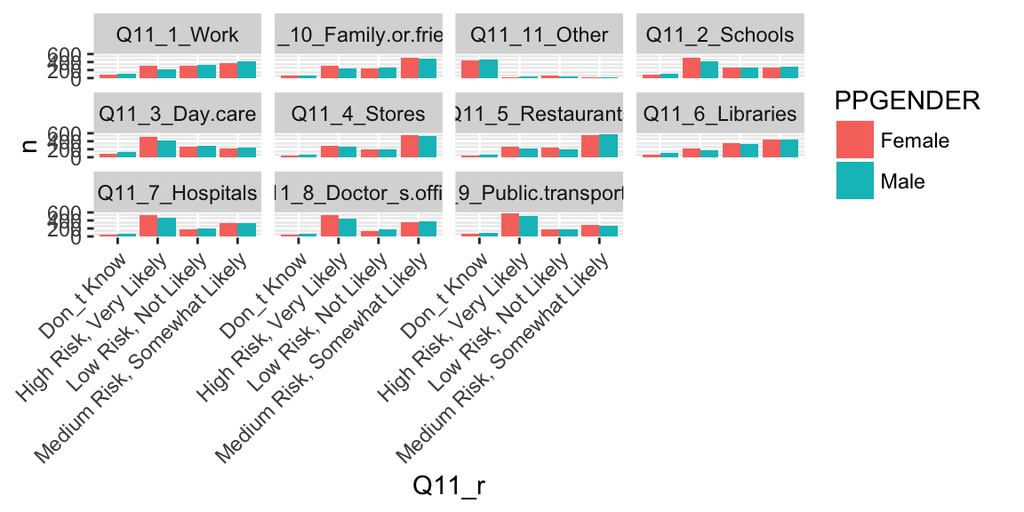

```
## , , Q11_q = Q11_1_Work
##
##                         Q11_r
## PPETHM                   Don_t Know High Risk, Very Likely
##   White, Non-Hispanic           119                    381
##   Black, Non-Hispanic            22                     42
##   Hispanic                       27                     59
##   Other, Non-Hispanic             6                     22
##   2+ Races, Non-Hispanic         11                     20
##                         Q11_r
## PPETHM                   Low Risk, Not Likely Medium Risk, Somewhat Likely
##   White, Non-Hispanic                     468                          586
##   Black, Non-Hispanic                      65                           64
##   Hispanic                                 61                           83
##   Other, Non-Hispanic                      25                           38
##   2+ Races, Non-Hispanic                   24                           24
##
## , , Q11_q = Q11_10_Family.or.friends
##
##                         Q11_r
## PPETHM                   Don_t Know High Risk, Very Likely
##   White, Non-Hispanic            65                    379
##   Black, Non-Hispanic            19                     53
##   Hispanic                       20                     68
##   Other, Non-Hispanic            10                     21
##   2+ Races, Non-Hispanic          7                     20
##                         Q11_r
## PPETHM                   Low Risk, Not Likely Medium Risk, Somewhat Likely
##   White, Non-Hispanic                     355                          755
##   Black, Non-Hispanic                      41                           80
##   Hispanic                                 37                          105
##   Other, Non-Hispanic                      26                           34
##   2+ Races, Non-Hispanic                   26                           26
##
## , , Q11_q = Q11_11_Other
##
##                         Q11_r
## PPETHM                   Don_t Know High Risk, Very Likely
##   White, Non-Hispanic           655                     34
##   Black, Non-Hispanic            90                      4
```

[output cut: 131 more lines]

```
##
##                         Q11_r
## PPETHM                   Don_t Know High Risk, Very Likely
##   White, Non-Hispanic            91                    797
##   Black, Non-Hispanic            22                     88
##   Hispanic                       20                    124
##   Other, Non-Hispanic             8                     51
##   2+ Races, Non-Hispanic          6                     33
##                         Q11_r
## PPETHM                   Low Risk, Not Likely Medium Risk, Somewhat Likely
##   White, Non-Hispanic                     259                          406
##   Black, Non-Hispanic                      41                           42
##   Hispanic                                 27                           57
##   Other, Non-Hispanic                      11                           21
##   2+ Races, Non-Hispanic                   15                           25
```

[figure not shown]

```
## , , Q11_r = Don_t Know
##
##                       Q11_q
## PPINCIMP               Q11_1_Work Q11_10_Family.or.friends Q11_11_Other
##   Less than $5,000             14                       14           22
##   $5,000 to $7,499              7                        5           15
##   $7,500 to $9,999              5                        2            4
##   $10,000 to $12,499            4                        4           25
##   $12,500 to $14,999            8                        8           20
##   $15,000 to $19,999           12                        8           29
##   $20,000 to $24,999           10                        7           27
##   $25,000 to $29,999           10                        3           41
##   $30,000 to $34,999           11                        6           42
##   $35,000 to $39,999           10                        6           39
##   $40,000 to $49,999            9                        8           71
##   $50,000 to $59,999           16                        7           75
##   $60,000 to $74,999           14                       10           91
##   $75,000 to $84,999           14                       10           73
##   $85,000 to $99,999            7                        3           58
##   $100,000 to $124,999         17                        9          146
##   $125,000 to $149,999          6                        4           61
##   $150,000 to $174,999          4                        1           25
##   $175,000 or more              7                        6           51
##                       Q11_q
## PPINCIMP               Q11_2_Schools Q11_3_Day.care Q11_4_Stores
##   Less than $5,000                15             14           12
##   $5,000 to $7,499                 5              6            5
##   $7,500 to $9,999                 4              4            3
##   $10,000 to $12,499               3              4            2
##   $12,500 to $14,999               7             10            6
##   $15,000 to $19,999              12             12           10
##   $20,000 to $24,999               7              8            5
##   $25,000 to $29,999               9             10            3
##   $30,000 to $34,999              10             11            6
##   $35,000 to $39,999              12             15            6
##   $40,000 to $49,999              11             10            7
##   $50,000 to $59,999              14             19            6
##   $60,000 to $74,999              18             19           12
##   $75,000 to $84,999              12             17            8
##   $85,000 to $99,999               5              6            3
```

[output cut: 292 more lines]

```
##   $12,500 to $14,999                      12                          10
##   $15,000 to $19,999                      19                          15
##   $20,000 to $24,999                      24                          27
##   $25,000 to $29,999                      30                          18
##   $30,000 to $34,999                      27                          19
##   $35,000 to $39,999                      33                          23
##   $40,000 to $49,999                      43                          36
##   $50,000 to $59,999                      64                          40
##   $60,000 to $74,999                      74                          54
##   $75,000 to $84,999                      54                          39
##   $85,000 to $99,999                      56                          43
##   $100,000 to $124,999                   124                          98
##   $125,000 to $149,999                    48                          38
##   $150,000 to $174,999                    34                          25
##   $175,000 or more                        42                          29
```

[figure not shown]

### Q12. Which of the following actions do you take to avoid getting sick?

```
##                                                      r
## q                                                     Always Never
##   Q12_1_Avoid.touching.my.eyes                           653   324
##   Q12_10_Get.recommended.vaccine                        1041   564
##   Q12_11_Take.preventive.medicine                        425   831
##   Q12_12_Cover.my.nose.and.mouth.with.a.surgical.mask    218  1568
##   Q12_13_Avoid.contact.with.people.who.are.sick          765   153
##   Q12_14_Avoid.crowded.places                            406   413
##   Q12_15_Other                                            91   472
##   Q12_2_Avoid.touching.my.nose                           613   349
##   Q12_3_Avoid.touching.my.mouth                          758   300
##   Q12_4_Wash.my.hands.with.soap.more.often              1774    52
##   Q12_5_Use.hand.sanitizers                              911   278
##   Q12_6_Clean.the.surfaces.in.my.home                   1132   115
##   Q12_7_Clean.the.surfaces.at.work                       752   544
##   Q12_8_Eat.nutritious.food                              895   107
##   Q12_9_Get.adequate.rest                                899   114
##                                                      r
## q                                                     Sometimes
##   Q12_1_Avoid.touching.my.eyes                             1168
##   Q12_10_Get.recommended.vaccine                            540
##   Q12_11_Take.preventive.medicine                           890
##   Q12_12_Cover.my.nose.and.mouth.with.a.surgical.mask       358
##   Q12_13_Avoid.contact.with.people.who.are.sick            1228
##   Q12_14_Avoid.crowded.places                              1322
##   Q12_15_Other                                               87
##   Q12_2_Avoid.touching.my.nose                             1183
##   Q12_3_Avoid.touching.my.mouth                            1085
##   Q12_4_Wash.my.hands.with.soap.more.often                  317
##   Q12_5_Use.hand.sanitizers                                 957
##   Q12_6_Clean.the.surfaces.in.my.home                       899
##   Q12_7_Clean.the.surfaces.at.work                          842
##   Q12_8_Eat.nutritious.food                                1144
##   Q12_9_Get.adequate.rest                                  1130
```

### Q13. Do you get the flu vaccine?

```
## Q13
## Yes, every year Yes, some years       No, never
##             908             423             819
```

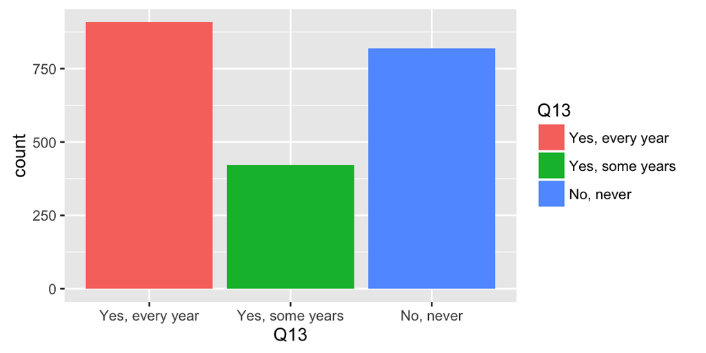

```
##                  PPGENDER
## Q13               Female Male
##   Yes, every year    460  448
##   Yes, some years    227  196
##   No, never          408  411
```

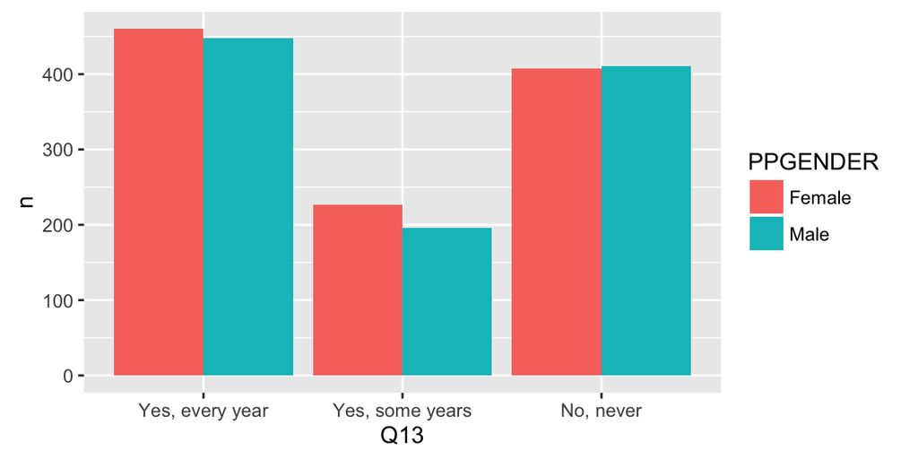

```
##                  PPINCIMP
## Q13               Less than $5,000 $5,000 to $7,499 $7,500 to $9,999
##   Yes, every year               15                4                5
##   Yes, some years                4                9                2
##   No, never                     33               11                6
##                  PPINCIMP
## Q13               $10,000 to $12,499 $12,500 to $14,999 $15,000 to $19,999
##   Yes, every year                 21                 15                 23
##   Yes, some years                 11                  9                  5
##   No, never                       24                 23                 34
##                  PPINCIMP
## Q13               $20,000 to $24,999 $25,000 to $29,999 $30,000 to $34,999
##   Yes, every year                 24                 38                 35
##   Yes, some years                 11                 18                 21
##   No, never                       37                 42                 36
##                  PPINCIMP
## Q13               $35,000 to $39,999 $40,000 to $49,999 $50,000 to $59,999
##   Yes, every year                 41                 64                 80
##   Yes, some years                 17                 25                 33
##   No, never                       46                 59                 70
##                  PPINCIMP
## Q13               $60,000 to $74,999 $75,000 to $84,999 $85,000 to $99,999
##   Yes, every year                 88                 55                 76
##   Yes, some years                 45                 40                 34
##   No, never                       88                 64                 42
##                  PPINCIMP
## Q13               $100,000 to $124,999 $125,000 to $149,999
##   Yes, every year                  148                   65
##   Yes, some years                   70                   29
##   No, never                        108                   38
##                  PPINCIMP
## Q13               $150,000 to $174,999 $175,000 or more
##   Yes, every year                   45               66
##   Yes, some years                   15               25
##   No, never                         24               34
```

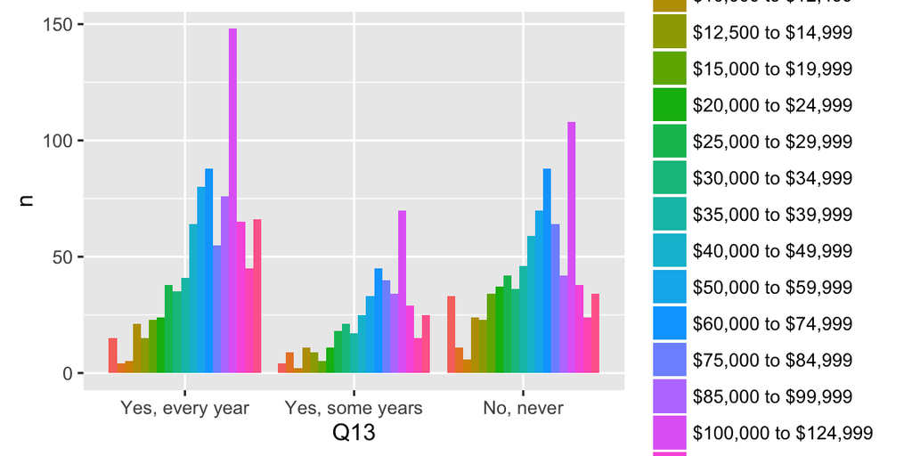

### Q14. How much do you pay to get an influenza vaccine?

```
## Q14
##            $0 Less than $30    $30 to $60 More than $60    Don_t know
##           970           222            54             4            80
```

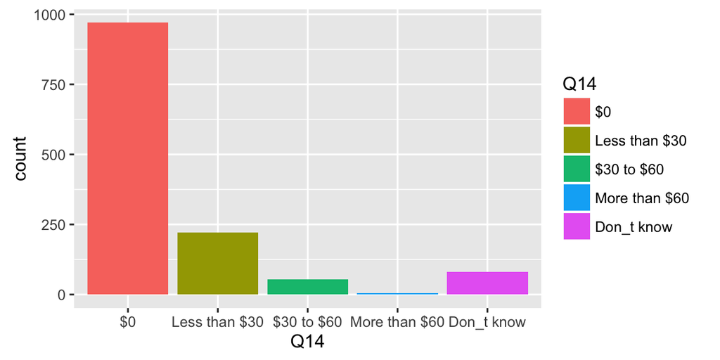

```
## PPGENDER: Female
##            $0 Less than $30    $30 to $60 More than $60    Don_t know
##           514           101            28             2            41
##          NA's
##           411
## --------------------------------------------------------
## PPGENDER: Male
##            $0 Less than $30    $30 to $60 More than $60    Don_t know
##           456           121            26             2            39
##          NA's
##           427
```

### Q15. Are you more likely to get a vaccine if others around you get a vaccine?

```
## Q15
##  No, less likely    No, no effect Yes, more likely
##               70              878              381
```

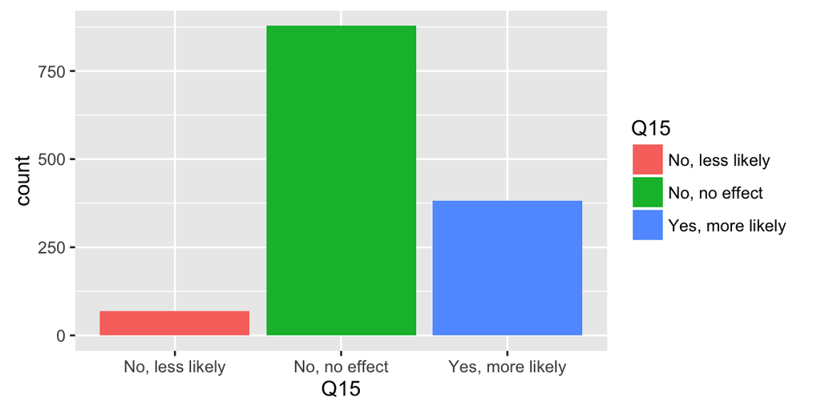

```
##                   PPGENDER
## Q15                Female Male
##   No, less likely      31   39
##   No, no effect       477  401
##   Yes, more likely    179  202
```

```
##                   PPETHM
## Q15                White, Non-Hispanic Black, Non-Hispanic Hispanic
##   No, less likely                   32                  17       14
##   No, no effect                    708                  53       69
##   Yes, more likely                 248                  36       51
##                   PPETHM
## Q15                Other, Non-Hispanic 2+ Races, Non-Hispanic
##   No, less likely                    5                      2
##   No, no effect                     27                     21
##   Yes, more likely                  32                     14
```

```
##                       Q15
## PPINCIMP               No, less likely No, no effect Yes, more likely
##   Less than $5,000                   3             6               10
##   $5,000 to $7,499                   2             6                5
##   $7,500 to $9,999                   1             4                2
##   $10,000 to $12,499                 5            16               11
##   $12,500 to $14,999                 0            13               10
##   $15,000 to $19,999                 1            15               12
##   $20,000 to $24,999                 0            25               10
##   $25,000 to $29,999                 4            34               17
##   $30,000 to $34,999                 2            39               15
##   $35,000 to $39,999                 3            38               17
##   $40,000 to $49,999                 5            58               26
##   $50,000 to $59,999                 8            78               27
##   $60,000 to $74,999                 9            85               39
##   $75,000 to $84,999                 4            67               24
##   $85,000 to $99,999                 5            79               26
##   $100,000 to $124,999               8           151               59
##   $125,000 to $149,999               6            60               28
##   $150,000 to $174,999               3            37               20
##   $175,000 or more                   1            67               23
```

### Q16. Are you more likely to get a vaccine if others around you do not get a vaccine?

```
## Q16
##  No, less likely    No, no effect Yes, more likely
##              101              904              313
```

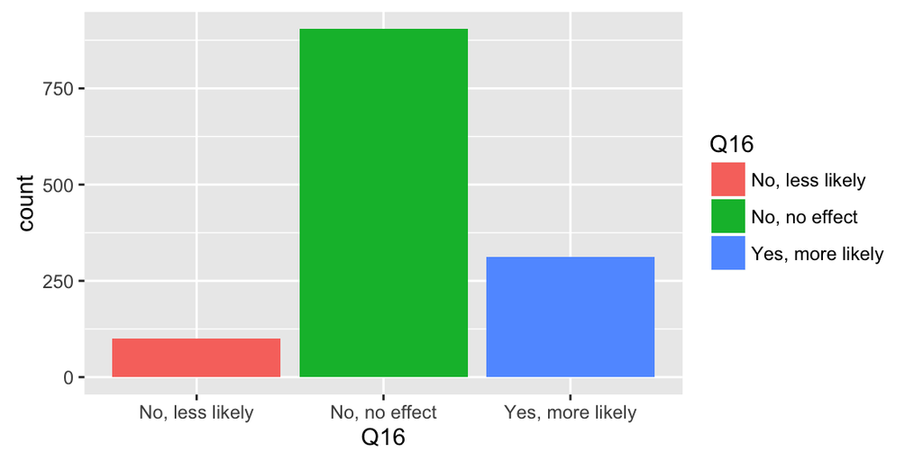

```
##                   PPGENDER
## Q16                Female Male
##   No, less likely      43   58
##   No, no effect       472  432
##   Yes, more likely    162  151
```

```
##                   PPETHM
## Q16                White, Non-Hispanic Black, Non-Hispanic Hispanic
##   No, less likely                   58                  11       18
##   No, no effect                    721                  61       69
##   Yes, more likely                 198                  34       47
##                   PPETHM
## Q16                Other, Non-Hispanic 2+ Races, Non-Hispanic
##   No, less likely                   11                      3
##   No, no effect                     30                     23
##   Yes, more likely                  22                     12
```

```
##                       Q16
## PPINCIMP               No, less likely No, no effect Yes, more likely
##   Less than $5,000                   2             8                9
##   $5,000 to $7,499                   3             7                3
##   $7,500 to $9,999                   0             4                3
##   $10,000 to $12,499                 3            18               11
##   $12,500 to $14,999                 4            10                9
##   $15,000 to $19,999                 0            16               12
##   $20,000 to $24,999                 4            21                8
##   $25,000 to $29,999                 2            34               20
##   $30,000 to $34,999                 3            41               11
##   $35,000 to $39,999                 5            37               16
##   $40,000 to $49,999                 9            54               24
##   $50,000 to $59,999                 9            77               26
##   $60,000 to $74,999                 9            97               27
##   $75,000 to $84,999                 8            65               21
##   $85,000 to $99,999                 7            83               19
##   $100,000 to $124,999              13           156               47
##   $125,000 to $149,999              11            65               17
##   $150,000 to $174,999               5            40               14
##   $175,000 or more                   4            71               16
```

### Q17. Do you get a vaccine to protect yourself, protect others, or protect yourself and others?

```
## Q17
##            Protect myself Protect myself and others
##                       381                       921
##            Protect others
##                        22
```

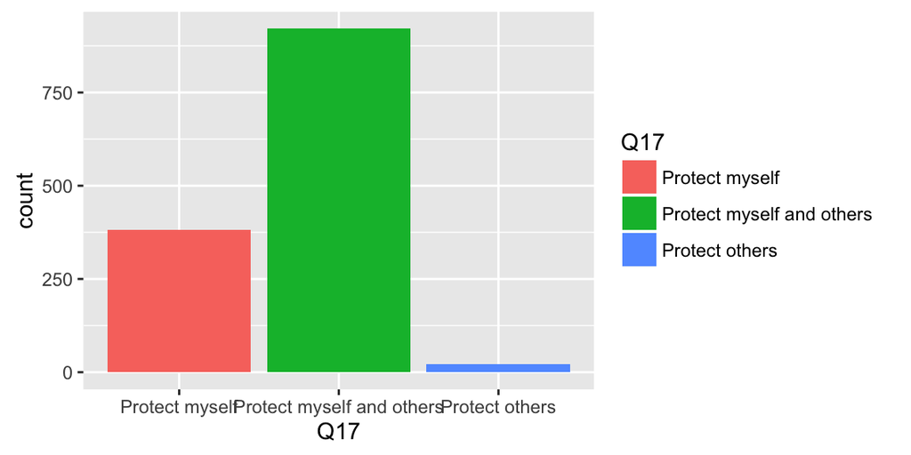

```
##                            PPGENDER
## Q17                         Female Male
##   Protect myself               175  206
##   Protect myself and others    500  421
##   Protect others                 9   13
```

```
##                            PPETHM
## Q17                         White, Non-Hispanic Black, Non-Hispanic
##   Protect myself                            291                  32
##   Protect myself and others                 682                  69
##   Protect others                             13                   2
##                            PPETHM
## Q17                         Hispanic Other, Non-Hispanic
##   Protect myself                  35                  15
##   Protect myself and others       93                  47
##   Protect others                   5                   2
##                            PPETHM
## Q17                         2+ Races, Non-Hispanic
##   Protect myself                                 8
##   Protect myself and others                     30
##   Protect others                                 0
```

```
##                       Q17
## PPINCIMP               Protect myself Protect myself and others
##   Less than $5,000                  7                        10
##   $5,000 to $7,499                  4                         9
##   $7,500 to $9,999                  2                         5
##   $10,000 to $12,499               10                        21
##   $12,500 to $14,999                4                        18
##   $15,000 to $19,999               11                        17
##   $20,000 to $24,999               13                        21
##   $25,000 to $29,999               19                        35
##   $30,000 to $34,999               16                        40
##   $35,000 to $39,999               14                        43
##   $40,000 to $49,999               20                        69
##   $50,000 to $59,999               29                        78
##   $60,000 to $74,999               38                        90
##   $75,000 to $84,999               30                        63
##   $85,000 to $99,999               31                        76
##   $100,000 to $124,999             63                       153
##   $125,000 to $149,999             29                        64
##   $150,000 to $174,999             14                        45
##   $175,000 or more                 27                        64
##                       Q17
## PPINCIMP               Protect others
##   Less than $5,000                  1
##   $5,000 to $7,499                  0
##   $7,500 to $9,999                  0
##   $10,000 to $12,499                1
##   $12,500 to $14,999                2
##   $15,000 to $19,999                0
##   $20,000 to $24,999                0
##   $25,000 to $29,999                2
##   $30,000 to $34,999                0
##   $35,000 to $39,999                1
##   $40,000 to $49,999                0
##   $50,000 to $59,999                4
##   $60,000 to $74,999                4
##   $75,000 to $84,999                2
##   $85,000 to $99,999                3
##   $100,000 to $124,999              2
##   $125,000 to $149,999              0
##   $150,000 to $174,999              0
##   $175,000 or more                  0
```

### Q18. What are the reasons you would not get an influenza vaccine?

```
##                                                                  r
## q                                                                   No
##   Q18_1_The.vaccine.costs.too.much                                1132
##   Q18_10_Other                                                    1064
##   Q18_2_The.vaccine.is.not.very.effective.in.preventing.influenza  903
##   Q18_3_I.am.not.likely.to.get.influenza                           964
##   Q18_4_Do.not.know.where.to.get.vaccine                          1199
##   Q18_5_The.side.effect.of.the.vaccine.are.too.risky               958
##   Q18_6_I.am.allergic.to.some.of.the.ingredients.in.the.vaccine   1184
##   Q18_7_I.do.not.like.shots                                        976
##   Q18_8_I.just.don_t.get.around.to.doing.it                        878
##   Q18_9_I.have.to.travel.too.far.to.get.vaccine                   1216
##                                                                  r
## q                                                                  Yes
##   Q18_1_The.vaccine.costs.too.much                                 110
##   Q18_10_Other                                                     178
##   Q18_2_The.vaccine.is.not.very.effective.in.preventing.influenza  339
##   Q18_3_I.am.not.likely.to.get.influenza                           278
##   Q18_4_Do.not.know.where.to.get.vaccine                            43
##   Q18_5_The.side.effect.of.the.vaccine.are.too.risky               284
##   Q18_6_I.am.allergic.to.some.of.the.ingredients.in.the.vaccine     58
##   Q18_7_I.do.not.like.shots                                        266
##   Q18_8_I.just.don_t.get.around.to.doing.it                        364
##   Q18_9_I.have.to.travel.too.far.to.get.vaccine                     26
```

### Q19. Do you have health insurance?

```
## Q19
##   No  Yes
##  154 1994
```

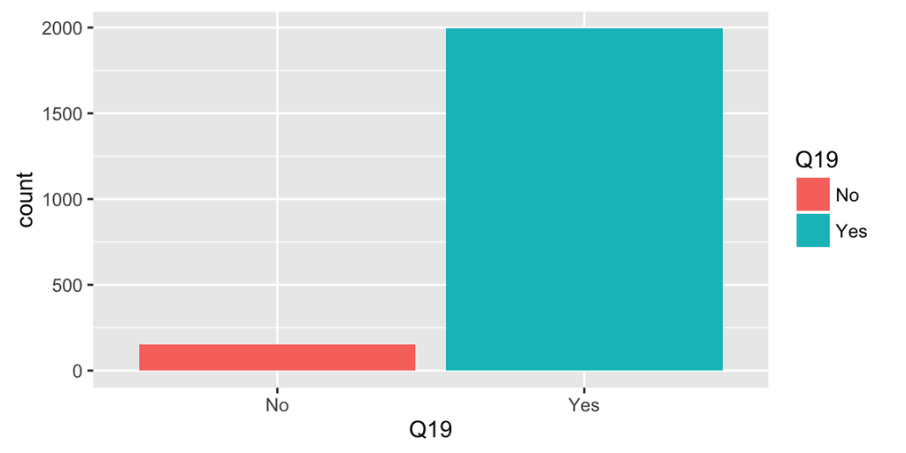

```
##      PPGENDER
## Q19   Female Male
##   No      60   94
##   Yes   1033  961
```

```
##      PPETHM
## Q19   White, Non-Hispanic Black, Non-Hispanic Hispanic Other, Non-Hispanic
##   No                   77                  19       40                   8
##   Yes                1478                 174      188                  85
##      PPETHM
## Q19   2+ Races, Non-Hispanic
##   No                      10
##   Yes                     69
```

```
##                       Q19
## PPINCIMP                No Yes
##   Less than $5,000      18  33
##   $5,000 to $7,499       5  20
##   $7,500 to $9,999       2  12
##   $10,000 to $12,499     8  48
##   $12,500 to $14,999    10  37
##   $15,000 to $19,999     8  54
##   $20,000 to $24,999    13  59
##   $25,000 to $29,999     7  91
##   $30,000 to $34,999    10  80
##   $35,000 to $39,999     8  96
##   $40,000 to $49,999    10 138
##   $50,000 to $59,999     7 176
##   $60,000 to $74,999    14 206
##   $75,000 to $84,999     9 151
##   $85,000 to $99,999     7 146
##   $100,000 to $124,999   7 318
##   $125,000 to $149,999   4 128
##   $150,000 to $174,999   2  81
##   $175,000 or more       5 120
```

### Q20. How effective do you think the influenza vaccine is in protecting people from becoming sick with influenza?

```
## Q20
##                  Very effective              Somewhat effective
##                             383                             961
## It varies from season to season                   Not effective
##                             433                             144
##                      Don_t know
##                             228
```

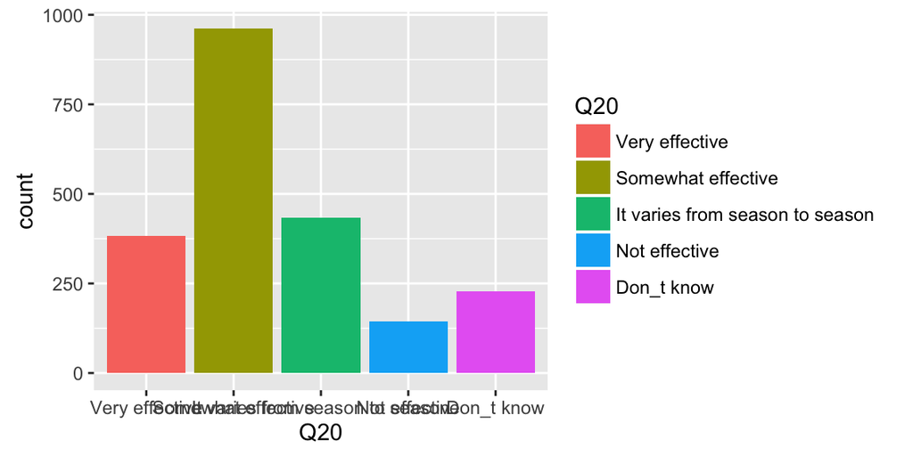

```
##                                  PPGENDER
## Q20                               Female Male
##   Very effective                     205  178
##   Somewhat effective                 464  497
##   It varies from season to season    243  190
##   Not effective                       73   71
##   Don_t know                         110  118
```

```
##                                  PPETHM
## Q20                               White, Non-Hispanic Black, Non-Hispanic
##   Very effective                                  280                  34
##   Somewhat effective                              712                  82
##   It varies from season to season                 333                  30
##   Not effective                                    94                  14
##   Don_t know                                      135                  34
##                                  PPETHM
## Q20                               Hispanic Other, Non-Hispanic
##   Very effective                        41                  14
##   Somewhat effective                   101                  36
##   It varies from season to season       31                  24
##   Not effective                         21                   4
##   Don_t know                            35                  15
##                                  PPETHM
## Q20                               2+ Races, Non-Hispanic
##   Very effective                                      14
##   Somewhat effective                                  30
##   It varies from season to season                     15
##   Not effective                                       11
##   Don_t know                                           9
```

```
##                       Q20
## PPINCIMP               Very effective Somewhat effective
##   Less than $5,000                 14                  9
##   $5,000 to $7,499                  5                  7
##   $7,500 to $9,999                  2                  4
##   $10,000 to $12,499                8                 28
##   $12,500 to $14,999                9                 10
##   $15,000 to $19,999               10                 23
##   $20,000 to $24,999               15                 26
##   $25,000 to $29,999               16                 47
##   $30,000 to $34,999               14                 35
##   $35,000 to $39,999               23                 37
##   $40,000 to $49,999               28                 59
##   $50,000 to $59,999               38                 75
##   $60,000 to $74,999               23                106
##   $75,000 to $84,999               25                 71
##   $85,000 to $99,999               26                 81
##   $100,000 to $124,999             62                165
##   $125,000 to $149,999             28                 71
##   $150,000 to $174,999             20                 38
##   $175,000 or more                 17                 69
##                       Q20
## PPINCIMP               It varies from season to season Not effective
##   Less than $5,000                                   6             5
##   $5,000 to $7,499                                   3             0
##   $7,500 to $9,999                                   1             2
##   $10,000 to $12,499                                 9             5
##   $12,500 to $14,999                                18             5
##   $15,000 to $19,999                                14             3
##   $20,000 to $24,999                                14             7
##   $25,000 to $29,999                                17             6
##   $30,000 to $34,999                                16             6
##   $35,000 to $39,999                                19             9
##   $40,000 to $49,999                                37            11
##   $50,000 to $59,999                                45            10
##   $60,000 to $74,999                                45            19
##   $75,000 to $84,999                                33            14
##   $85,000 to $99,999                                30             6
##   $100,000 to $124,999                              60            24
##   $125,000 to $149,999                              22             2
```

[output cut: 8 more lines]

```
##   $12,500 to $14,999            5
##   $15,000 to $19,999           12
##   $20,000 to $24,999           10
##   $25,000 to $29,999           12
##   $30,000 to $34,999           19
##   $35,000 to $39,999           16
##   $40,000 to $49,999           12
##   $50,000 to $59,999           15
##   $60,000 to $74,999           28
##   $75,000 to $84,999           17
##   $85,000 to $99,999           10
##   $100,000 to $124,999         15
##   $125,000 to $149,999          9
##   $150,000 to $174,999          2
##   $175,000 or more              7
```

### Q21. Are influenza vaccines covered by your health insurance?

```
## Q21
##             Yes, the full cost is paid
##                                   1282
## Yes, but only part of the cost is paid
##                                    153
##                                     No
##                                     55
##                             Don_t know
##                                    500
```

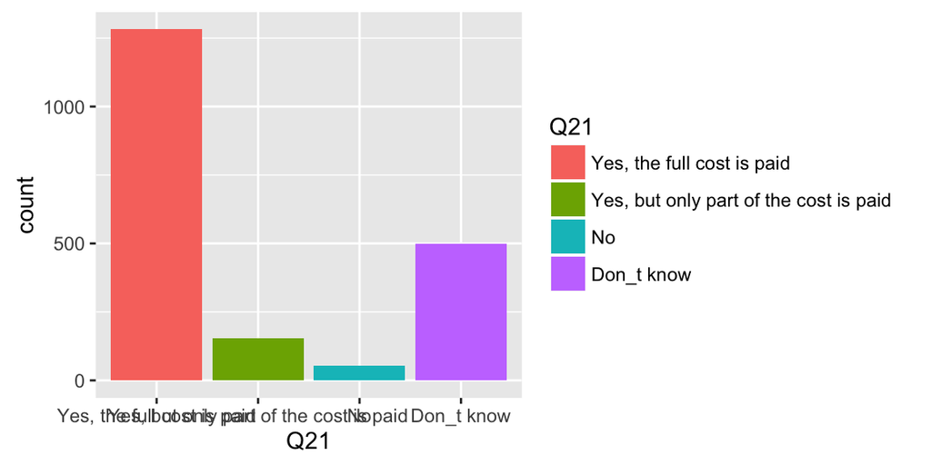

```
##                                         PPGENDER
## Q21                                      Female Male
##   Yes, the full cost is paid                670  612
##   Yes, but only part of the cost is paid     60   93
##   No                                         31   24
##   Don_t know                                271  229
```

```
##                                         PPETHM
## Q21                                      White, Non-Hispanic
##   Yes, the full cost is paid                             945
##   Yes, but only part of the cost is paid                 112
##   No                                                      44
##   Don_t know                                             374
##                                         PPETHM
## Q21                                      Black, Non-Hispanic Hispanic
##   Yes, the full cost is paid                             124      118
##   Yes, but only part of the cost is paid                  10       17
##   No                                                       5        2
##   Don_t know                                              34       51
##                                         PPETHM
## Q21                                      Other, Non-Hispanic
##   Yes, the full cost is paid                              46
##   Yes, but only part of the cost is paid                  10
##   No                                                       2
##   Don_t know                                              27
##                                         PPETHM
## Q21                                      2+ Races, Non-Hispanic
##   Yes, the full cost is paid                                 49
##   Yes, but only part of the cost is paid                      4
##   No                                                          2
##   Don_t know                                                 14
```

```
##                       Q21
## PPINCIMP               Yes, the full cost is paid
##   Less than $5,000                             19
##   $5,000 to $7,499                             13
##   $7,500 to $9,999                              6
##   $10,000 to $12,499                           34
##   $12,500 to $14,999                           21
##   $15,000 to $19,999                           27
##   $20,000 to $24,999                           36
##   $25,000 to $29,999                           56
##   $30,000 to $34,999                           47
##   $35,000 to $39,999                           63
##   $40,000 to $49,999                           82
##   $50,000 to $59,999                          116
##   $60,000 to $74,999                          125
##   $75,000 to $84,999                           98
##   $85,000 to $99,999                          104
##   $100,000 to $124,999                        213
##   $125,000 to $149,999                         89
##   $150,000 to $174,999                         61
##   $175,000 or more                             72
##                       Q21
## PPINCIMP               Yes, but only part of the cost is paid  No
##   Less than $5,000                                          1   2
##   $5,000 to $7,499                                          0   0
##   $7,500 to $9,999                                          1   1
##   $10,000 to $12,499                                        1   3
##   $12,500 to $14,999                                        3   1
##   $15,000 to $19,999                                        1   2
##   $20,000 to $24,999                                        4   1
##   $25,000 to $29,999                                        7   1
##   $30,000 to $34,999                                        4   4
##   $35,000 to $39,999                                        7   1
##   $40,000 to $49,999                                       18   4
##   $50,000 to $59,999                                       13   6
##   $60,000 to $74,999                                       13   6
##   $75,000 to $84,999                                       12   2
##   $85,000 to $99,999                                        9   2
##   $100,000 to $124,999                                     26   9
##   $125,000 to $149,999                                      9   7
```

[output cut: 8 more lines]

```
##   $12,500 to $14,999           12
##   $15,000 to $19,999           24
##   $20,000 to $24,999           18
##   $25,000 to $29,999           27
##   $30,000 to $34,999           25
##   $35,000 to $39,999           25
##   $40,000 to $49,999           34
##   $50,000 to $59,999           40
##   $60,000 to $74,999           62
##   $75,000 to $84,999           39
##   $85,000 to $99,999           31
##   $100,000 to $124,999         68
##   $125,000 to $149,999         23
##   $150,000 to $174,999         12
##   $175,000 or more             29
```

### Q22. Do you do any of the following when you have influenza symptoms?

```
##                                                                     r
## q                                                                    Always
##   Q22_1_Go.to.a.doctor_s.office.or.medical.clinic                       349
##   Q22_2_Decide.on.treatment.without.consulting.a.health.practitioner    335
##   Q22_3_Search.the.internet.for.a.treatment                             126
##   Q22_4_Get.adequate.sleep                                             1147
##   Q22_5_Eat.nutritious.food                                             909
##   Q22_6_Take-over-counter.medication.for.symptoms                       796
##   Q22_7_Take.an.antiviral.medicine                                      153
##   Q22_8_Take.no.action.to.treat.the.illness                              96
##   Q22_9_Other                                                            54
##                                                                     r
## q                                                                    Never
##   Q22_1_Go.to.a.doctor_s.office.or.medical.clinic                      552
##   Q22_2_Decide.on.treatment.without.consulting.a.health.practitioner   473
##   Q22_3_Search.the.internet.for.a.treatment                           1148
##   Q22_4_Get.adequate.sleep                                             115
##   Q22_5_Eat.nutritious.food                                            135
##   Q22_6_Take-over-counter.medication.for.symptoms                      210
##   Q22_7_Take.an.antiviral.medicine                                    1103
##   Q22_8_Take.no.action.to.treat.the.illness                           1199
##   Q22_9_Other                                                          448
##                                                                     r
## q                                                                    Sometimes
##   Q22_1_Go.to.a.doctor_s.office.or.medical.clinic                         1235
##   Q22_2_Decide.on.treatment.without.consulting.a.health.practitioner      1329
##   Q22_3_Search.the.internet.for.a.treatment                                861
##   Q22_4_Get.adequate.sleep                                                 875
##   Q22_5_Eat.nutritious.food                                               1091
##   Q22_6_Take-over-counter.medication.for.symptoms                         1130
##   Q22_7_Take.an.antiviral.medicine                                         877
##   Q22_8_Take.no.action.to.treat.the.illness                                839
##   Q22_9_Other                                                               38
```

### Q23. Which of the following actions do you take when you have influenza symptoms to avoid someone else from getting sick?

```
##                                                        r
## q                                                       Always Never
##   Q23_1_Stand.away.from.people                            1006   135
##   Q23_10_Cover.my.nose.and.mouth.when.I.sneeze.or.cough   1717    81
##   Q23_11_Other                                              54   421
##   Q23_2_Avoid.public.places                                897   196
##   Q23_3_Avoid.public.transportation                       1342   245
##   Q23_4_Stay.at.home                                       869   163
##   Q23_5_Wash.my.hands.with.soap.more.often                1559    92
##   Q23_6_Use.hand.sanitizers                               1014   299
##   Q23_7_Clean.the.surfaces.in.my.home                     1151   153
##   Q23_8_Clean.the.surfaces.I.use.at.work                   856   508
##   Q23_9_Cover.my.nose.and.mouth.with.a.surgical.mask       267  1463
##                                                        r
## q                                                       Sometimes
##   Q23_1_Stand.away.from.people                                996
##   Q23_10_Cover.my.nose.and.mouth.when.I.sneeze.or.cough       341
##   Q23_11_Other                                                 28
##   Q23_2_Avoid.public.places                                  1044
##   Q23_3_Avoid.public.transportation                           550
##   Q23_4_Stay.at.home                                         1106
##   Q23_5_Wash.my.hands.with.soap.more.often                    488
##   Q23_6_Use.hand.sanitizers                                   825
##   Q23_7_Clean.the.surfaces.in.my.home                         832
##   Q23_8_Clean.the.surfaces.I.use.at.work                      772
##   Q23_9_Cover.my.nose.and.mouth.with.a.surgical.mask          409
```

### Q24. What sources of information do you recall hearing or seeing about influenza outbreaks?

```
##                                                       r
## q                                                        No  Yes
##   Q24_1_Print.media.such.as.newspapers.and.magazines   1460  708
##   Q24_2_Traditional.media.such.as.television.and.radio  811 1357
##   Q24_3_Social.media.such.as.internet.and.blogs        1680  488
##   Q24_4_Word.of.mouth                                  1213  955
##   Q24_5_None                                           1764  404
##   Q24_6_Other                                          2114   54
```

### Q25. If you received information from the news, internet or other public media that there was an influenza outbreak in your community would you do any of the following?

```
##                                                        r
## q                                                       Always Never
##   Q25_1_Stand.away.from.people                             649   217
##   Q25_10_Cover.my.nose.and.mouth.when.I.sneeze.or.cough   1643    90
##   Q25_11_Other                                              32   393
##   Q25_2_Avoid.public.places                                648   270
##   Q25_3_Avoid.public.transportation                       1221   268
##   Q25_4_Stay.at.home                                       484   429
##   Q25_5_Wash.my.hands.with.soap.more.often                1477    99
##   Q25_6_Use.hand.sanitizers                               1077   257
##   Q25_7_Clean.the.surfaces.in.my.home                     1116   160
##   Q25_8_Clean.the.surfaces.I.use.at.work                   902   464
##   Q25_9_Cover.my.nose.and.mouth.with.a.surgical.mask       343  1286
##                                                        r
## q                                                       Sometimes
##   Q25_1_Stand.away.from.people                               1268
##   Q25_10_Cover.my.nose.and.mouth.when.I.sneeze.or.cough       399
##   Q25_11_Other                                                 21
##   Q25_2_Avoid.public.places                                  1217
##   Q25_3_Avoid.public.transportation                           643
##   Q25_4_Stay.at.home                                         1222
##   Q25_5_Wash.my.hands.with.soap.more.often                    554
##   Q25_6_Use.hand.sanitizers                                   799
##   Q25_7_Clean.the.surfaces.in.my.home                         857
##   Q25_8_Clean.the.surfaces.I.use.at.work                      766
##   Q25_9_Cover.my.nose.and.mouth.with.a.surgical.mask          505
```

### Q26. Does your household have children?

```
## Q26
##   No  Yes
## 1570  576
```

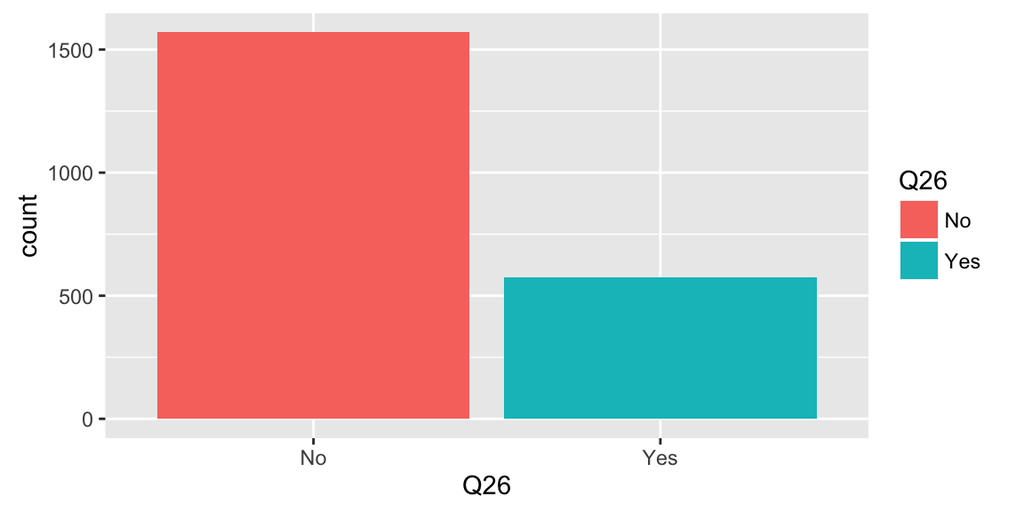

### Q27. What actions do you take when a child in your household has influenza symptoms?

```
##                                                             r
## q                                                            Always Never
##   Q27_1_Keep.the.child.away.from.the.others.in.the.residence    198    90
##   Q27_2_Keep.the.child.out.of.school-daycare                    377    46
##   Q27_3_Stop.child_s.social.activities.like.play.dates          388    41
##   Q27_4_Other                                                    12    93
##                                                             r
## q                                                            Sometimes
##   Q27_1_Keep.the.child.away.from.the.others.in.the.residence       285
##   Q27_2_Keep.the.child.out.of.school-daycare                       149
##   Q27_3_Stop.child_s.social.activities.like.play.dates             144
##   Q27_4_Other                                                       12
```

### Q28. Are you a single parent?

```
## Q28
##  No Yes
## 490  86
```

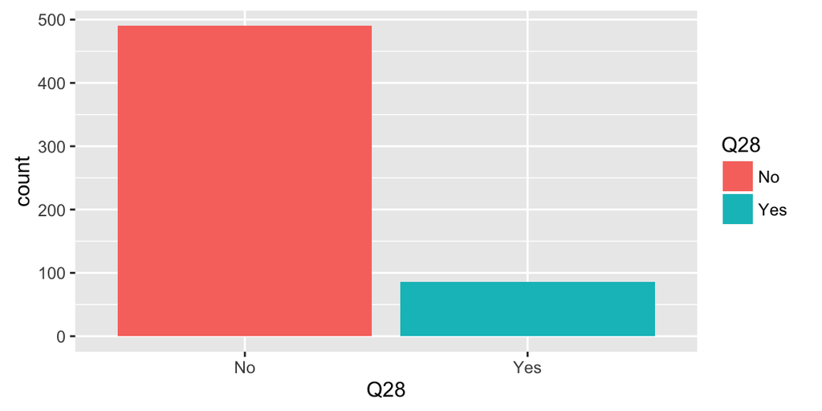

### Q29. How do you care for a sick child?

```
##                                                r
## q                                               Always Never Sometimes
##   Q29_1_A.parent.brings.the.child.to.work            7   438        41
##   Q29_2_A.parent.stays.home                        266    27       193
##   Q29_3_Another.adult.stays.home                    68   202       216
##   Q29_4_Send.the.child.to.school.sick                1   414        70
##   Q29_5_Take.the.child.to.a.relative.or.friends      8   292       186
##   Q29_6_Other                                        4    76         6
```

### Q30. How do you care for a sick child?

```
##                                                r
## q                                               Always Never Sometimes
##   Q30_1_I.bring.the.child.to.work                    4    77         5
##   Q30_2_I.stay.home                                 34    10        42
##   Q30_3_Another.adult.stays.home                     9    25        52
##   Q30_4_Send.the.child.to.school.sick                3    60        23
##   Q30_5_Take.the.child.to.a.relative.or.friends      7    33        46
##   Q30_6_Other                                        1    14         3
```

### Q31. How many hours of screen time (time spent watching television, a computer, smartphone, iPad, etc.) do you spend each day on average when you are not sick? Enter 0 if none

```
##    Min. 1st Qu.  Median    Mean 3rd Qu.    Max.    NA's
##     0.0     2.0     4.0     4.9     6.0    24.0      52
```

```
## PPGENDER: Female
##    Min. 1st Qu.  Median    Mean 3rd Qu.    Max.    NA's
##    0.00    2.00    4.00    4.84    6.00   21.00      21
## --------------------------------------------------------
## PPGENDER: Male
##    Min. 1st Qu.  Median    Mean 3rd Qu.    Max.    NA's
##     0.0     2.0     4.0     4.9     6.0    24.0      31
```

```
## PPETHM: White, Non-Hispanic
##    Min. 1st Qu.  Median    Mean 3rd Qu.    Max.    NA's
##    0.00    2.00    4.00    4.69    6.00   22.00      29
## --------------------------------------------------------
## PPETHM: Black, Non-Hispanic
##    Min. 1st Qu.  Median    Mean 3rd Qu.    Max.    NA's
##    0.00    3.00    5.00    5.93    8.00   24.00       6
## --------------------------------------------------------
## PPETHM: Hispanic
##    Min. 1st Qu.  Median    Mean 3rd Qu.    Max.    NA's
##    0.00    2.00    4.00    5.05    7.00   24.00       9
## --------------------------------------------------------
## PPETHM: Other, Non-Hispanic
##    Min. 1st Qu.  Median    Mean 3rd Qu.    Max.    NA's
##    0.00    2.00    4.00    4.48    5.25   15.00       5
## --------------------------------------------------------
## PPETHM: 2+ Races, Non-Hispanic
##    Min. 1st Qu.  Median    Mean 3rd Qu.    Max.    NA's
##    0.00    2.00    4.00    5.68    8.00   20.00       3
```

```
## PPINCIMP: Less than $5,000
##    Min. 1st Qu.  Median    Mean 3rd Qu.    Max.    NA's
##     0.0     1.0     4.0     4.7     6.0    20.0       3
## --------------------------------------------------------
## PPINCIMP: $5,000 to $7,499
##    Min. 1st Qu.  Median    Mean 3rd Qu.    Max.    NA's
##    0.00    2.75    4.00    5.46    7.25   20.00       1
## --------------------------------------------------------
## PPINCIMP: $7,500 to $9,999
##    Min. 1st Qu.  Median    Mean 3rd Qu.    Max.    NA's
##    0.00    3.00    4.00    6.08   11.00   14.00       1
## --------------------------------------------------------
## PPINCIMP: $10,000 to $12,499
##    Min. 1st Qu.  Median    Mean 3rd Qu.    Max.    NA's
##    0.00    2.00    4.00    4.85    7.00   16.00       1
## --------------------------------------------------------
## PPINCIMP: $12,500 to $14,999
##    Min. 1st Qu.  Median    Mean 3rd Qu.    Max.    NA's
##    0.00    3.00    5.00    5.78    8.00   20.00       3
## --------------------------------------------------------
## PPINCIMP: $15,000 to $19,999
##    Min. 1st Qu.  Median    Mean 3rd Qu.    Max.    NA's
##    0.00    2.00    4.00    5.13    6.00   24.00       1
## --------------------------------------------------------
## PPINCIMP: $20,000 to $24,999
##    Min. 1st Qu.  Median    Mean 3rd Qu.    Max.    NA's
##    0.00    3.00    5.00    5.36    6.00   22.00       4
## --------------------------------------------------------
## PPINCIMP: $25,000 to $29,999
##    Min. 1st Qu.  Median    Mean 3rd Qu.    Max.    NA's
##    0.00    3.00    4.50    5.18    6.00   18.00       1
## --------------------------------------------------------
## PPINCIMP: $30,000 to $34,999
##    Min. 1st Qu.  Median    Mean 3rd Qu.    Max.    NA's
##    0.00    2.75    4.00    4.89    6.00   15.00       5
## --------------------------------------------------------
## PPINCIMP: $35,000 to $39,999
##    Min. 1st Qu.  Median    Mean 3rd Qu.    Max.    NA's
##    0.00    2.00    4.00    4.83    7.00   18.00       3
## --------------------------------------------------------
```

[output cut: 20 more lines]

```
## PPINCIMP: $100,000 to $124,999
##    Min. 1st Qu.  Median    Mean 3rd Qu.    Max.    NA's
##    0.00    2.00    4.00    4.98    7.00   24.00       4
## --------------------------------------------------------
## PPINCIMP: $125,000 to $149,999
##    Min. 1st Qu.  Median    Mean 3rd Qu.    Max.    NA's
##    0.00    2.00    4.00    5.04    7.00   20.00       1
## --------------------------------------------------------
## PPINCIMP: $150,000 to $174,999
##    Min. 1st Qu.  Median    Mean 3rd Qu.    Max.    NA's
##    1.00    2.00    4.00    4.66    6.00   20.00       3
## --------------------------------------------------------
## PPINCIMP: $175,000 or more
##    Min. 1st Qu.  Median    Mean 3rd Qu.    Max.    NA's
##    0.00    2.00    3.00    4.37    6.00   15.00       3
```

### Q32. How many hours of screen time do you spend each day on average when you are sick? Enter 0 if none

```
##    Min. 1st Qu.  Median    Mean 3rd Qu.    Max.    NA's
##     0.0     1.0     4.0     4.3     6.0    24.0      61
```

```
## PPGENDER: Female
##    Min. 1st Qu.  Median    Mean 3rd Qu.    Max.    NA's
##    0.00    1.00    4.00    4.18    6.00   24.00      29
## --------------------------------------------------------
## PPGENDER: Male
##    Min. 1st Qu.  Median    Mean 3rd Qu.    Max.    NA's
##     0.0     1.0     4.0     4.4     6.0    24.0      32
```

```
## PPETHM: White, Non-Hispanic
##    Min. 1st Qu.  Median    Mean 3rd Qu.    Max.    NA's
##     0.0     1.0     4.0     4.3     6.0    24.0      39
## --------------------------------------------------------
## PPETHM: Black, Non-Hispanic
##    Min. 1st Qu.  Median    Mean 3rd Qu.    Max.    NA's
##    0.00    1.00    3.00    4.52    7.00   24.00       6
## --------------------------------------------------------
## PPETHM: Hispanic
##    Min. 1st Qu.  Median    Mean 3rd Qu.    Max.    NA's
##    0.00    1.00    3.00    4.17    6.00   20.00       8
## --------------------------------------------------------
## PPETHM: Other, Non-Hispanic
##    Min. 1st Qu.  Median    Mean 3rd Qu.    Max.    NA's
##    0.00    1.00    2.00    3.10    4.25   12.00       5
## --------------------------------------------------------
## PPETHM: 2+ Races, Non-Hispanic
##    Min. 1st Qu.  Median    Mean 3rd Qu.    Max.    NA's
##    0.00    2.00    5.00    5.42    8.00   20.00       3
```

```
## PPINCIMP: Less than $5,000
##    Min. 1st Qu.  Median    Mean 3rd Qu.    Max.    NA's
##    0.00    0.00    2.00    3.84    5.00   24.00       4
## --------------------------------------------------------
## PPINCIMP: $5,000 to $7,499
##    Min. 1st Qu.  Median    Mean 3rd Qu.    Max.
##    0.00    1.00    2.00    4.92    7.00   24.00
## --------------------------------------------------------
## PPINCIMP: $7,500 to $9,999
##    Min. 1st Qu.  Median    Mean 3rd Qu.    Max.    NA's
##    0.00    0.00    2.00    3.67    7.25   12.00       2
## --------------------------------------------------------
## PPINCIMP: $10,000 to $12,499
##    Min. 1st Qu.  Median    Mean 3rd Qu.    Max.    NA's
##    0.00    0.00    3.00    4.07    6.00   15.00       2
## --------------------------------------------------------
## PPINCIMP: $12,500 to $14,999
##    Min. 1st Qu.  Median    Mean 3rd Qu.    Max.    NA's
##    0.00    1.00    2.50    3.93    5.75   20.00       2
## --------------------------------------------------------
## PPINCIMP: $15,000 to $19,999
##    Min. 1st Qu.  Median    Mean 3rd Qu.    Max.    NA's
##    0.00    0.00    2.00    3.67    5.00   18.00       2
## --------------------------------------------------------
## PPINCIMP: $20,000 to $24,999
##    Min. 1st Qu.  Median    Mean 3rd Qu.    Max.    NA's
##    0.00    2.00    5.00    5.07    8.00   20.00       5
## --------------------------------------------------------
## PPINCIMP: $25,000 to $29,999
##    Min. 1st Qu.  Median    Mean 3rd Qu.    Max.    NA's
##    0.00    1.00    3.00    4.48    7.00   22.00       1
## --------------------------------------------------------
## PPINCIMP: $30,000 to $34,999
##    Min. 1st Qu.  Median    Mean 3rd Qu.    Max.    NA's
##    0.00    2.00    4.00    4.16    6.25   12.00       5
## --------------------------------------------------------
## PPINCIMP: $35,000 to $39,999
##    Min. 1st Qu.  Median    Mean 3rd Qu.    Max.    NA's
##    0.00    1.00    3.00    4.22    6.00   18.00       3
## --------------------------------------------------------
```

[output cut: 20 more lines]

```
## PPINCIMP: $100,000 to $124,999
##    Min. 1st Qu.  Median    Mean 3rd Qu.    Max.    NA's
##    0.00    2.00    4.00    4.47    6.00   24.00       4
## --------------------------------------------------------
## PPINCIMP: $125,000 to $149,999
##    Min. 1st Qu.  Median    Mean 3rd Qu.    Max.    NA's
##    0.00    2.00    5.00    4.66    6.00   20.00       1
## --------------------------------------------------------
## PPINCIMP: $150,000 to $174,999
##    Min. 1st Qu.  Median    Mean 3rd Qu.    Max.    NA's
##    0.00    2.00    4.00    4.54    6.00   20.00       2
## --------------------------------------------------------
## PPINCIMP: $175,000 or more
##    Min. 1st Qu.  Median    Mean 3rd Qu.    Max.    NA's
##    0.00    1.00    3.50    4.09    6.00   20.00       4
```

### Q33. How many people, including yourself, reside in your household?

```
##    Min. 1st Qu.  Median    Mean 3rd Qu.    Max.    NA's
##    1.00    2.00    2.00    2.58    3.00   14.00      28
```

```
## PPGENDER: Female
##    Min. 1st Qu.  Median    Mean 3rd Qu.    Max.    NA's
##    1.00    2.00    2.00    2.57    3.00    9.00       8
## --------------------------------------------------------
## PPGENDER: Male
##    Min. 1st Qu.  Median    Mean 3rd Qu.    Max.    NA's
##    1.00    2.00    2.00    2.59    3.00   14.00      20
```

[output not shown]

[output not shown]

[output cut: 20 more lines]

[output not shown]